# Acitivy 03: Summary statistics, frequency distribution, and basic graphical representation

Jerome Poblete

01 June 2026

# A. Read and perform descriptive statistics

1. Read in the CSV file

We use the base R function `read.csv()`, which returns a `data.frame`. The data is cleaned prior to performing any tasks. We do **not** clean the data in Excel but rather do it all in R via its subset operations.

```r
# NOTE: Ensure the CSV file is in the parent directory!
df <- read.csv("../herpetozoa-033-095-s001.csv")
df <- df[complete.cases(df), ]
```

Recall than in R, subsets operate on a row, column basis. Think of this like y, x rather than x, y. Also recall than these ‘indexes’ can be logical data frames themselves. So the line `df[complete.cases(df), ]` selects all rows with non-empty data and selects all their columns as we assume all column headers are valid.

2. Show the data structure

Printing builtin data structures in simple enough. Their type name can be retrieved via `class()` and a simple representation via `str()`. If there is a non-empty return value, R implicitly prints that. There is no need to explicitly call `print()`.

```r
class(df)
```

```
## [1] "data.frame"
```

```r
str(df)
```

```
## 'data.frame':    49 obs. of  33 variables:
##  $ Sites   : chr  "ASG_ET1#" "ASG_ET4#" "ESG_ET5#" "CVT_ET6" ...
##  $ Long    : num  118 118 118 118 118 ...
##  $ Lat     : num  9.37 9.37 9.37 9.37 9.37 ...
##  $ Htypes  : chr  "ASG" "ASG" "ESG" "CVT" ...
##  $ Elev    : int  257 215 188 105 662 754 814 1020 474 425 ...
##  $ SPPTotal: int  0 0 0 0 1 1 1 1 1 1 ...
##  $ Babu    : int  0 0 0 0 0 0 0 0 0 0 ...
##  $ Inph    : int  0 0 0 0 0 0 0 0 0 0 ...
##  $ Liac    : int  0 0 0 0 0 0 0 0 0 0 ...
##  $ Lipa    : int  0 0 0 0 0 0 0 0 0 0 ...
##  $ Ocla    : int  0 0 0 0 0 0 0 0 0 0 ...
##  $ Leta    : int  0 0 0 0 0 0 0 0 0 0 ...
##  $ Meli    : int  0 0 0 0 0 0 0 0 0 0 ...
##  $ Chfu    : int  0 0 0 0 0 0 0 0 0 0 ...
```

[output cut: 19 more lines]

3. Subset the elevation data

Like before we use the R subset operations to filter from the given data frame. We are selecting all rows of the `Elev` column specifically.

```r
elev.data <- df[, "Elev"]
elev.data
```

```
##  [1]  257  215  188  105  662  754  814 1020  474  425  507  537  686  778  147  259  353  170  819  783  590  399  374
## [24]  619  752  120  163  164  537  346  354  439  291  229  364  343  233  140  219  370  423  189  113   60  146  210
## [47]  140  227   83
```

We can also provide the following summary statistics:

```r
mean(elev.data)
```

```
## [1] 379.3878
```

```r
sd(elev.data)
```

```
## [1] 240.5951
```

```r
range(elev.data)
```

```
## [1]   60 1020
```

# B. Graphical representation

1. Scatterplot

We create a scatter plot of total species count, elevation, and habitat types using the base R `plot()`function. We also colorize it for better visualization.

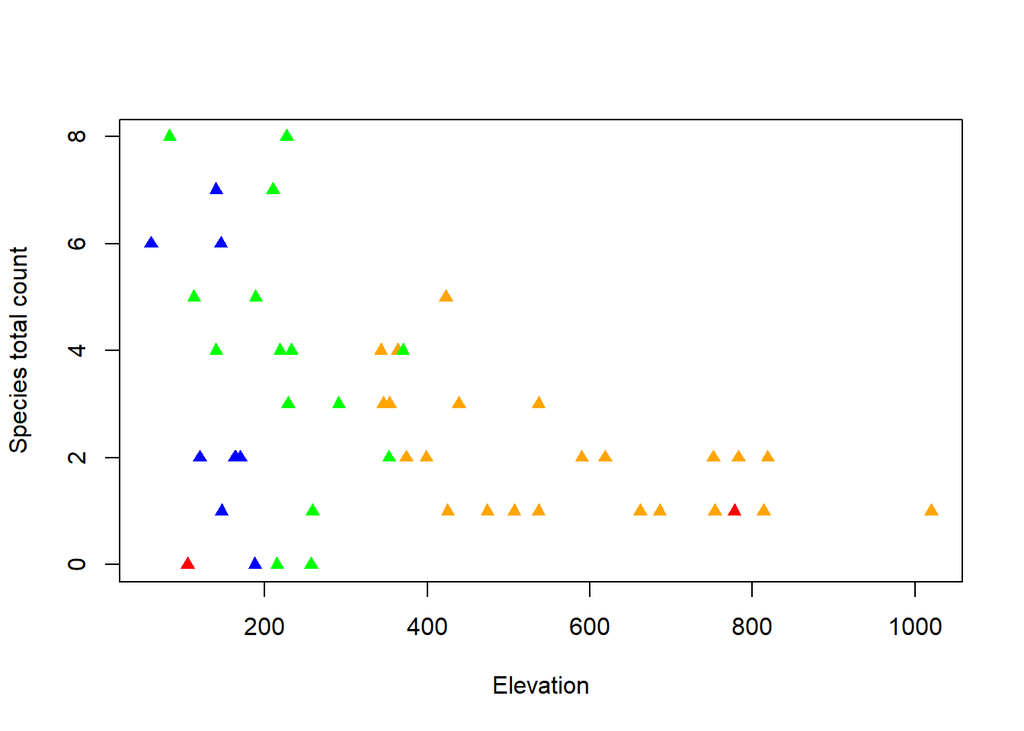

Elevation and total species count.

```r
htypes.colors_map <- c(ASG="green", ESG="blue", CVT="red", OGF="orange")
htypes.colors <- sapply(df[, "Htypes"], function(k) {htypes.colors_map[k]})
plot(x    = df[, "Elev"],
     y    = df[, "SPPTotal"],
     xlab = "Elevation",
     ylab = "Species total count",
     col  = htypes.colors,
     bg   = htypes.colors,
     pch  = 17)
```

2. Bar plot

We create a bar plot of habitat type and species count using the base R `barplot()` function.

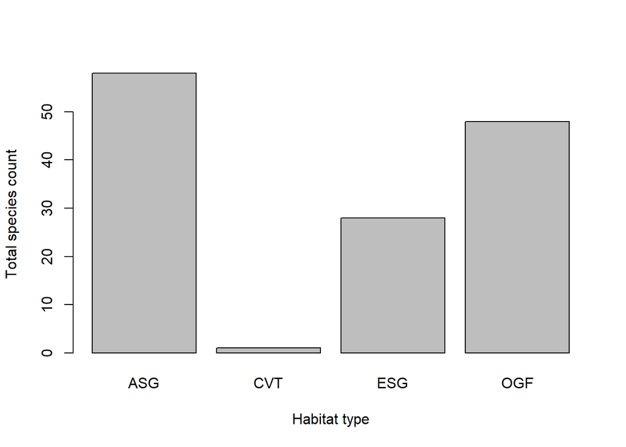

Habitat type and total species count.

```r
d <- df[, c("SPPTotal", "Elev", "Htypes")]
barplot(
  height = sapply(split(d, d$Htypes), function(v) sum(v$SPPTotal)),
  xlab   = "Habitat type",
  ylab   = "Total species count"
)
```

3. Histogram

We create a histogram of the frequency of each species total count using the base R `hist()` function.

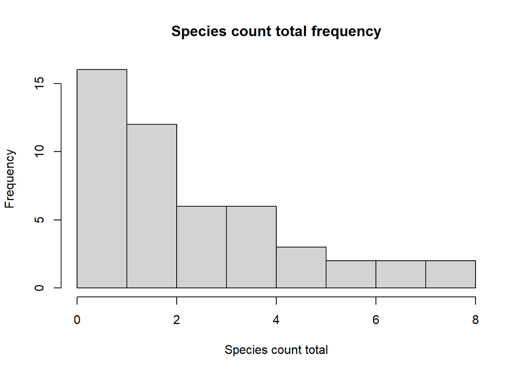

Species total count frequency.

```r
hist(df[, "SPPTotal"], xlab="Species count total", main="Species count total frequency")
```

# C. Interpretation

The total count of species observed seems to have a very loose inverse relationship with elevation. That is, in the Elevation-Species total count scatterplot, increasing elevation leads to decrease in species count. Species also seem to be most abundant at ASG and least abundant at CVT. This may explain by lower counts of species are more common than higher ones as seen in the histogram.